# COVID Research

Ke’Shondra Reed

August 13, 2020

## 0.1 **Introduction**

I am doing a project for Biology 390 Reproducible Research at Ferris State University Summer 2020 semester. I worked with dataset to create reproducible research report online. During the first outbreak of the coronavirus in 2019 I was not that concerned with the virus because it wasn’t in the United State. I actually thought it was funny because there were memes all over social media about Michiganders, and that we will drink ginger ales to get rid of any flu and cold like symptoms. As some people like myself may have not known that this is not the first coronavirus outbreak. The first large outbreak was 18 years ago and was refer to as the severe acute respiratory syndrome-related coronaviruses (SARS-CoV). The source of this outbreak was found in bats, and studies showed that it could infect humans. A new outbreak refers to as the novel coronavirus(2019-nCoV) that were first reported on December 12, 2019 in China, and causing a widespread of acute respiratory syndrome in humans, and there were 56 deaths reported by January 2020. I created a hypothesis to explore. This project is under version control using git/Github and is written as an R markdown (Rmd) file to create graphs and table.

## 0.2 **Hypothesis**

I am choosing to do data sets on cases in china and the rest of the world. My hypothesis is that China would have numerous of cases and death since it originated from there as well as it would spread to other parts of the world.I knew and thought it would spread because of traveling. Also I think that the spread and total cases will decrease faster in China than other parts of the World.

## 0.3 **Data**

- The raw data was put togeter by Johns Hopkins University Center for Systems Science and Engineering https://systems.jhu.edu/research/public-health/ncov/

## 0.4 **Analyses**

### 0.4.1 *COVID Cases in the World*

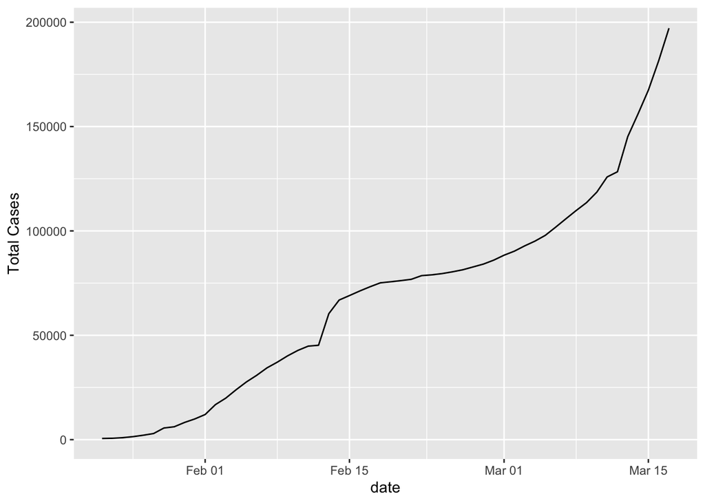

### 0.4.2 *China VS. The World*

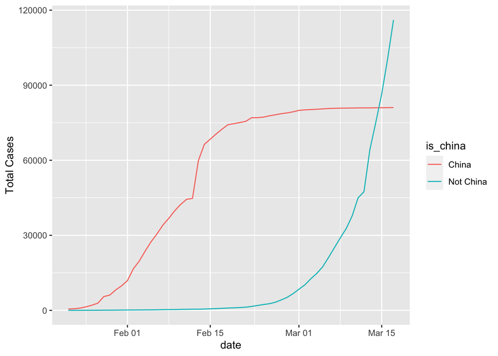

### 0.4.3 *China Trend Line*

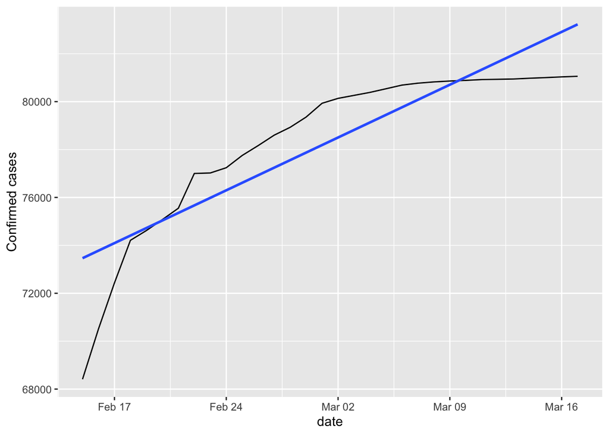

### 0.4.4 *The Rest of The World Trend*

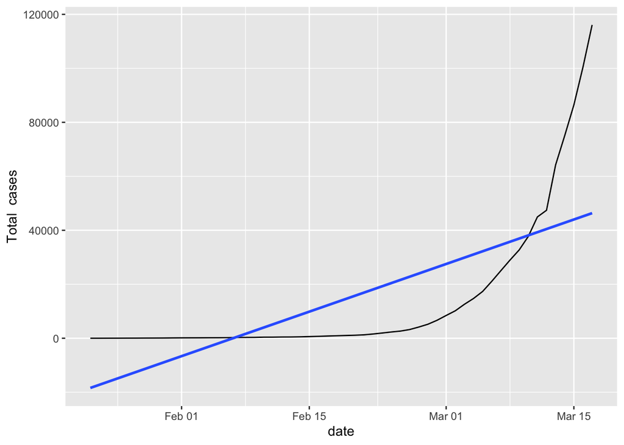

- This figure is similar to the one above but this one is showing the rest of the world with a trend line. The rest of the world case began to increase in March, as expected.

### 0.4.5 *Countries with Highest Cases in March*

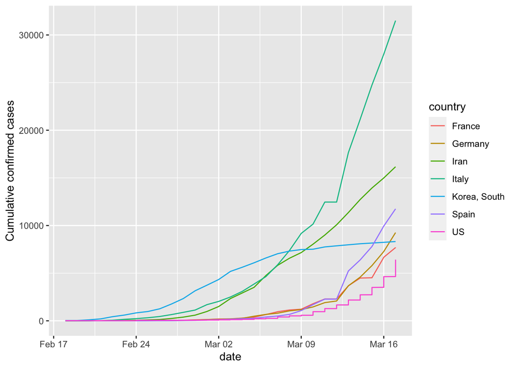

- This last figure is showing other countries that had higher cases, Italy having the highest total cases durning March.

## 0.5 **Conclusion**

In conclusion my hypothesis was correct, COVID 19 did spread to other countries and when it did the cases were at higher rate than China.